# GIT REPOSITORY LINK

https://github.com/carolinemariew/Python-group-3

# Project Group - 3

**Members & student numbers:**  
Caroline Aalders - 5230578  
Pangiotis Papadopoulos - 5054443  
Vendankur Kedar - 5693136  
Thieme Brandwagt - 5232910

# Introduction

The European Union has a big focus on sustainability with the European Green Deal that has been presented. The European union thrives to become climate neutral by the year 2050. When focusing on transport, one of the goals is to have doubled in high-speed rail traffic across Europe (European Commission, 2020). Therefore, for this project, the focus is on the modal shift from air travel to international train travel for the past ten years. Additionally, a case study on France its domestic travel numbers is introduced. France has multiple domestic flights and a vast high speed rail network. France is chosen, because it is the only EU nation that has publically published the data on both domestic aviation, as well as domestic high speed train service. Therefore, a thorough analysis can be made on different geographic scales within the EU.

References:

1. European Commission. (2020). The Transport and Mobility Sector. In European Commission.

# Research Objective

**Our main research question:**  
What is the trend in the modal shift from air travel to international train travel from the last ten years within the European Union?

**Our sub research questions:**  
What is the trend of air travel in the last ten years within the European Union?  
What is the trend of train travel in the last ten years within the European Union?  
What is the correlation between air travel and train travel in the last ten years within the European Union?  
What is the trend of the modal shift to high speed train within France?

# Contribution Statement

**Caroline Aalders**: Manager of background research.

**Vedankur Kedar**: Manager of data visualisation in graphs (and possibly maps).

**Panagiotis Papapoulos**: Manager of data modelling and coding logic.

**Thieme Brandwagt**: Manager of conceptualisation of theory and relevant policy.

# Data Considered

1. **Data on W.I.P. EU transport policy:** https ://www.consilium.europa.eu/en/policies/?filters=1650 (Relevant: Clean and sustainable mobility, European Green Deal, Rail Transport Policy)
2. **Data on historal EU rail policy directives:** https://www.europarl.europa.eu/factsheets/en/sheet/130/rail-transport#:~:text=The%20directive%20was%20amended%20by%20Directive%202001%2F13%2FEC%20of,Directive%202012%2F34%2FEU%20of%2021%20November%202012%20establishing%20
3. **Emission Trading Scheme and aviation:** https://climate.ec.europa.eu/eu-action/aviation-and-eu-ets_en
4. **Total amount of aviation passengers, excluding international flights.** https://ec.europa.eu/eurostat/databrowser/view/TTR00012/default/line?lang=en
5. **International flights:** https://ec.europa.eu/eurostat/statistics-explained/index.php?title=Air_transport_statistics#Intra-EU_passenger_transport_was_almost_at_the_same_level_as_extra-EU_traffic_in_2021
6. **Passenger flight per region:** https://ec.europa.eu/eurostat/databrowser/view/TRAN_R_AVPA_NM/default/line?lang=en
7. **Specific airports:** https://www.eurocontrol.int/Economics/DailyOperatedSchedules-Airports.html
8. **Rail fares:** https://data.europa.eu/data/datasets/fares?locale=nl
9. **Plane fares:** https://old.datahub.io/dataset/european-flight-price-data
10. **Other EU airline data:** https://ec.europa.eu/eurostat/web/main/data/database
11. **Passengers Transported:** https://ec.europa.eu/eurostat/databrowser/view/RAIL_PA_TOTAL/default/table?lang=en
12. **Passengers transported (detailed reporting only) - (quarterly data):** https://ec.europa.eu/eurostat/databrowser/view/RAIL_PA_QUARTAL/default/table?lang=en
13. **Passenger transport by type of transport (detailed reporting only):** https://ec.europa.eu/eurostat/databrowser/view/RAIL_PA_TYPEPAS/default/table?lang=en
14. **International transport of passengers from the reporting country to the country of disembarkation:** https://ec.europa.eu/eurostat/databrowser/view/RAIL_PA_INTGONG/default/table?lang=en
15. **International transport of passengers from the country of embarkation to the reporting country:** https://ec.europa.eu/eurostat/databrowser/view/RAIL_PA_INTCMNG/default/table?lang=en
16. **Railway transport - national and international railway passengers transport by loading/unloading NUTS 2 region:** https://ec.europa.eu/eurostat/databrowser/view/TRAN_R_RAPA/default/table?lang=en
17. **Passengers by speed of train:** https://ec.europa.eu/eurostat/databrowser/view/RAIL_PA_SPEED/default/table?lang=en
18. **Passenger cars in accompanied passenger car railway transport, by type of transport:** https://ec.europa.eu/eurostat/databrowser/view/RAIL_PA_NBCAR/default/table?lang=en
19. **Passengers in accompanied passenger car railway transport, by type of transport:** https://ec.europa.eu/eurostat/databrowser/view/RAIL_PA_NBPASS/default/table?lang=en

# Data Used

After collecting a lot of datasets, it was narrowed down to three datasets.

1. **Air travel within Europe** https://ec.europa.eu/eurostat/databrowser/view/TTR00012/default/line?lang=en
2. **International train travel within Europe** https://ec.europa.eu/eurostat/databrowser/view/rail_pa_typepas__custom_7854806/default/table?lang=en
3. **High speed train travel France** https://ec.europa.eu/eurostat/databrowser/view/RAIL_PA_SPEED/default/table?lang=en

The data collected for air travel within Europe accounts for flights from the EU to outside the EU, flights within the EU and domestic flights. In order to make a distinction between the different catagories, the following distrubition has been used:

[figure not shown]

https://ec.europa.eu/eurostat/statistics-explained/index.php?title=Air_transport_statistics

**Disclaimer:**  
Not all the datasets are complete. The datasets for international train travel lacks data of the following countries: Hungary, The Netherlands and Belgium. Therefore, the analysis will not represent a complete real world situation.

# Data Pipeline

All the data needs to be combined in a graph over time with stamps for places when policies have changed. The passenger number difference is the greatest indicator of our main question. When considering the data, it is important to acknowledge that policy is not the only factor influencing passenger numbers, like ticket price and the COVID-19 pandemic.

Steps:

1. Data collection
2. Data cleaning and transformation
3. Data integration into a single dataset
4. Data aggregation for the most interesting time periods
5. Data analysis
6. Data enrichment with external factors, such as COVID events
7. Data presentation in graphs

# Datasets and Libraries needed

```python
import pandas as pd
import matplotlib.pyplot as plt
import plotly.express as px
import plotly.graph_objects as go
```

Functions to get the country names and groups for clear data presentation later on:

```python
# Dictionary mapping ISO country codes to country names
# We need this because the datasets use ISO abbreviations
iso_country_names = {
    'AT': 'Austria', 'BE': 'Belgium', 'BG': 'Bulgaria', 'CY': 'Cyprus',
    'CZ': 'Czech Republic', 'DE': 'Germany', 'DK': 'Denmark', 'EE': 'Estonia',
    'ES': 'Spain', 'FI': 'Finland', 'FR': 'France', 'EL': 'Greece',
    'HR': 'Croatia', 'HU': 'Hungary', 'IE': 'Ireland', 'IT': 'Italy',
    'LT': 'Lithuania', 'LU': 'Luxembourg', 'LV': 'Latvia', 'MT': 'Malta',
    'NL': 'Netherlands', 'PL': 'Poland', 'PT': 'Portugal', 'RO': 'Romania',
    'SE': 'Sweden', 'SI': 'Slovenia', 'SK': 'Slovakia',
}

def get_country_name(iso_code):
    return iso_country_names.get(iso_code.upper(), '???')
```

```python
#For the regression graph, colours can be given to different parts of Europe`
country_group_names = {
    ('Belgium', 'Netherlands', 'France', 'Ireland'): 'Western Europe',
    ('Russia', 'Belarus', 'Ukraine'): 'Eastern Europe',
    ('Spain', 'Portugal', 'Andorra', 'Italy', 'Malta', 'Gibraltar', 'San Marino', 'Vatican City'): 'Southern Europe',
    ('Austria', 'Germany', 'Poland', 'Czech Republic', 'Slovakia', 'Hungary', 'Switzerland', 'Croatia', 'Slovenia', 'Liechtenstein', 'Luxembourg', 'Monaco', 'San Marino', 'Vatican City', 'Bosnia and Herzegovina', 'Montenegro', 'Serbia', 'Albania', 'Macedonia'): 'Central Europe',
    ('Bulgaria', 'Cyprus', 'Greece', 'Macedonia', 'Romania', 'Serbia', 'Turkey', 'Albania', 'Kosovo', 'Montenegro', 'Bosnia and Herzegovina', 'Croatia', 'Slovenia'): 'Southeastern Europe',
    ('Denmark', 'Norway', 'Sweden', 'Finland', 'Iceland', 'Greenland', 'Faroe Islands', 'Aland Islands', 'Svalbard and Jan Mayen'): 'Northern Europe',
    ('United Kingdom', 'Switzerland', 'Iceland', 'Norway', 'Ireland', 'Andorra', 'Liechtenstein', 'Monaco', 'San Marino', 'Vatican City'): 'Other',
}

def get_country_group(country):
    for country_set, region in country_group_names.items():
        if country in country_set:
            return region

get_country_group('Sweden')
```

```
'Northern Europe'
```

```python
df_air_pas = pd.read_csv('Datasets/Air_transport_of_passengers_by_country.csv')

#normalize for inter EU flight only, flights to outside the EU and domestic flights are excluded
df_air_pas['OBS_VALUE'] = df_air_pas['OBS_VALUE'] * 0.378

# Fix the country names
for index, row in df_air_pas.iterrows():
    df_air_pas.at[index, 'geo'] = get_country_name(row['geo'])

df_air_pas

#https://ec.europa.eu/eurostat/databrowser/view/TTR00012/default/table?lang=en
```

|  | DATAFLOW | LAST UPDATE | freq | unit | tra_meas | tra_cov | schedule | geo | TIME_PERIOD | OBS_VALUE | OBS_FLAG |
| --- | --- | --- | --- | --- | --- | --- | --- | --- | --- | --- | --- |
| 0 | ESTAT:TTR00012(1.0) | 05/10/23 23:00:00 | A | PAS | PAS_CRD | TOTAL | TOT | Austria | 2011 | 9.502017e+06 | NaN |
| 1 | ESTAT:TTR00012(1.0) | 05/10/23 23:00:00 | A | PAS | PAS_CRD | TOTAL | TOT | Austria | 2012 | 9.815139e+06 | NaN |
| 2 | ESTAT:TTR00012(1.0) | 05/10/23 23:00:00 | A | PAS | PAS_CRD | TOTAL | TOT | Austria | 2013 | 9.733396e+06 | NaN |
| 3 | ESTAT:TTR00012(1.0) | 05/10/23 23:00:00 | A | PAS | PAS_CRD | TOTAL | TOT | Austria | 2014 | 9.971140e+06 | NaN |
| 4 | ESTAT:TTR00012(1.0) | 05/10/23 23:00:00 | A | PAS | PAS_CRD | TOTAL | TOT | Austria | 2015 | 1.011301e+07 | NaN |
| ... | ... | ... | ... | ... | ... | ... | ... | ... | ... | ... | ... |
| 319 | ESTAT:TTR00012(1.0) | 05/10/23 23:00:00 | A | PAS | PAS_CRD | TOTAL | TOT | Slovakia | 2018 | 1.056168e+06 | NaN |
| 320 | ESTAT:TTR00012(1.0) | 05/10/23 23:00:00 | A | PAS | PAS_CRD | TOTAL | TOT | Slovakia | 2019 | 1.073439e+06 | NaN |
| 321 | ESTAT:TTR00012(1.0) | 05/10/23 23:00:00 | A | PAS | PAS_CRD | TOTAL | TOT | Slovakia | 2020 | 1.892283e+05 | NaN |
| 322 | ESTAT:TTR00012(1.0) | 05/10/23 23:00:00 | A | PAS | PAS_CRD | TOTAL | TOT | Slovakia | 2021 | 2.427055e+05 | NaN |
| 323 | ESTAT:TTR00012(1.0) | 05/10/23 23:00:00 | A | PAS | PAS_CRD | TOTAL | TOT | Slovakia | 2022 | 7.342907e+05 | NaN |

324 rows × 11 columns

```python
df_train_pas = pd.read_csv('Datasets/rail_int_per_thousand_pas.csv')

# Normalize as values are per 1000 passengers
df_train_pas['OBS_VALUE'] = df_train_pas['OBS_VALUE'] * 1000

# Fix the country names
for index, row in df_train_pas.iterrows():
    df_train_pas.at[index, 'geo'] = get_country_name(row['geo'])

df_train_pas
```

|  | DATAFLOW | LAST UPDATE | freq | unit | tra_cov | geo | TIME_PERIOD | OBS_VALUE | OBS_FLAG |
| --- | --- | --- | --- | --- | --- | --- | --- | --- | --- |
| 0 | ESTAT:RAIL_PA_TYPEPAS(1.0) | 13/10/23 23:00:00 | A | THS_PAS | INTL | Austria | 2013 | 10371000.0 | NaN |
| 1 | ESTAT:RAIL_PA_TYPEPAS(1.0) | 13/10/23 23:00:00 | A | THS_PAS | INTL | Austria | 2014 | 10234000.0 | NaN |
| 2 | ESTAT:RAIL_PA_TYPEPAS(1.0) | 13/10/23 23:00:00 | A | THS_PAS | INTL | Austria | 2015 | 9667000.0 | NaN |
| 3 | ESTAT:RAIL_PA_TYPEPAS(1.0) | 13/10/23 23:00:00 | A | THS_PAS | INTL | Austria | 2016 | 9298000.0 | NaN |
| 4 | ESTAT:RAIL_PA_TYPEPAS(1.0) | 13/10/23 23:00:00 | A | THS_PAS | INTL | Austria | 2017 | 9269000.0 | NaN |
| ... | ... | ... | ... | ... | ... | ... | ... | ... | ... |
| 242 | ESTAT:RAIL_PA_TYPEPAS(1.0) | 13/10/23 23:00:00 | A | THS_PAS | INTL | Slovakia | 2018 | 3885000.0 | NaN |
| 243 | ESTAT:RAIL_PA_TYPEPAS(1.0) | 13/10/23 23:00:00 | A | THS_PAS | INTL | Slovakia | 2019 | 4184000.0 | NaN |
| 244 | ESTAT:RAIL_PA_TYPEPAS(1.0) | 13/10/23 23:00:00 | A | THS_PAS | INTL | Slovakia | 2020 | 1441000.0 | NaN |
| 245 | ESTAT:RAIL_PA_TYPEPAS(1.0) | 13/10/23 23:00:00 | A | THS_PAS | INTL | Slovakia | 2021 | 2288000.0 | NaN |
| 246 | ESTAT:RAIL_PA_TYPEPAS(1.0) | 13/10/23 23:00:00 | A | THS_PAS | INTL | Slovakia | 2022 | 4566000.0 | NaN |

247 rows × 9 columns

```python
df_population_eu = pd.read_csv('Datasets/eu_population.csv')

# Fix the country names
for index, row in df_population_eu.iterrows():
    df_population_eu.at[index, 'geo'] = get_country_name(row['geo'])

df_population_eu
```

|  | DATAFLOW | LAST UPDATE | freq | unit | age | sex | geo | TIME_PERIOD | OBS_VALUE | OBS_FLAG |
| --- | --- | --- | --- | --- | --- | --- | --- | --- | --- | --- |
| 0 | ESTAT:DEMO_PJAN(1.0) | 28/09/23 23:00:00 | A | NR | TOTAL | T | Austria | 2013 | 8451860 | NaN |
| 1 | ESTAT:DEMO_PJAN(1.0) | 28/09/23 23:00:00 | A | NR | TOTAL | T | Austria | 2014 | 8507786 | NaN |
| 2 | ESTAT:DEMO_PJAN(1.0) | 28/09/23 23:00:00 | A | NR | TOTAL | T | Austria | 2015 | 8584926 | NaN |
| 3 | ESTAT:DEMO_PJAN(1.0) | 28/09/23 23:00:00 | A | NR | TOTAL | T | Austria | 2016 | 8700471 | NaN |
| 4 | ESTAT:DEMO_PJAN(1.0) | 28/09/23 23:00:00 | A | NR | TOTAL | T | Austria | 2017 | 8772865 | NaN |
| ... | ... | ... | ... | ... | ... | ... | ... | ... | ... | ... |
| 290 | ESTAT:DEMO_PJAN(1.0) | 28/09/23 23:00:00 | A | NR | TOTAL | T | Slovakia | 2018 | 5443120 | NaN |
| 291 | ESTAT:DEMO_PJAN(1.0) | 28/09/23 23:00:00 | A | NR | TOTAL | T | Slovakia | 2019 | 5450421 | NaN |
| 292 | ESTAT:DEMO_PJAN(1.0) | 28/09/23 23:00:00 | A | NR | TOTAL | T | Slovakia | 2020 | 5457873 | NaN |
| 293 | ESTAT:DEMO_PJAN(1.0) | 28/09/23 23:00:00 | A | NR | TOTAL | T | Slovakia | 2021 | 5459781 | NaN |
| 294 | ESTAT:DEMO_PJAN(1.0) | 28/09/23 23:00:00 | A | NR | TOTAL | T | Slovakia | 2022 | 5434712 | NaN |

295 rows × 10 columns

```python
path_rail = './Datasets/rail_pa_speed_page_linear.csv'
fast_rail = pd.read_csv(path_rail, encoding ='Windows-1252')
fast_rail
```

|  | DATAFLOW | LAST UPDATE | freq | unit | vehicle | geo | TIME_PERIOD | OBS_VALUE | OBS_FLAG |
| --- | --- | --- | --- | --- | --- | --- | --- | --- | --- |
| 0 | ESTAT:RAIL_PA_SPEED(1.0) | 04-10-2023 23:00 | A | PAS | TRN_HSPD | AL | 2020 | 0.0 | NaN |
| 1 | ESTAT:RAIL_PA_SPEED(1.0) | 04-10-2023 23:00 | A | PAS | TRN_HSPD | AL | 2021 | 0.0 | NaN |
| 2 | ESTAT:RAIL_PA_SPEED(1.0) | 04-10-2023 23:00 | A | PAS | TRN_HSPD | BG | 2014 | NaN | z |
| 3 | ESTAT:RAIL_PA_SPEED(1.0) | 04-10-2023 23:00 | A | PAS | TRN_HSPD | EE | 2014 | NaN | z |
| 4 | ESTAT:RAIL_PA_SPEED(1.0) | 04-10-2023 23:00 | A | PAS | TRN_HSPD | EE | 2015 | NaN | z |
| ... | ... | ... | ... | ... | ... | ... | ... | ... | ... |
| 106 | ESTAT:RAIL_PA_SPEED(1.0) | 04-10-2023 23:00 | A | PAS | TRN_HSPD | TR | 2020 | 2833.0 | NaN |
| 107 | ESTAT:RAIL_PA_SPEED(1.0) | 04-10-2023 23:00 | A | PAS | TRN_HSPD | XK | 2018 | 0.0 | NaN |
| 108 | ESTAT:RAIL_PA_SPEED(1.0) | 04-10-2023 23:00 | A | PAS | TRN_HSPD | XK | 2019 | 0.0 | NaN |
| 109 | ESTAT:RAIL_PA_SPEED(1.0) | 04-10-2023 23:00 | A | PAS | TRN_HSPD | XK | 2020 | 0.0 | NaN |
| 110 | ESTAT:RAIL_PA_SPEED(1.0) | 04-10-2023 23:00 | A | PAS | TRN_HSPD | XK | 2021 | 0.0 | NaN |

111 rows × 9 columns

# Part 1 - Comparison passengers between air travel and train travel in Europe

```python
year_pas_data_air = df_air_pas.groupby('TIME_PERIOD')['OBS_VALUE'].sum().reset_index() #passenger data of air travel is grouped per year
year_pas_data_train = df_train_pas.groupby('TIME_PERIOD')['OBS_VALUE'].sum().reset_index() #passenger data of train travel is grouped per year
```

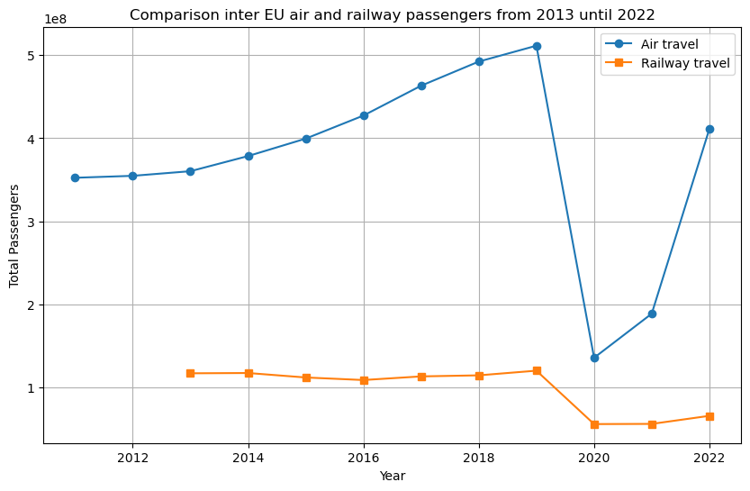

```python
fig, ax = plt.subplots(figsize=(10, 6)) #plotting the comparison of flight within the EU and international train travel

ax.plot(year_pas_data_air['TIME_PERIOD'], year_pas_data_air['OBS_VALUE'], label='Air travel', marker='o')
ax.plot(year_pas_data_train['TIME_PERIOD'], year_pas_data_train['OBS_VALUE'], label='Railway travel', marker='s')

ax.set_xlabel('Year')
ax.set_ylabel('Total Passengers')
ax.set_title('Comparison inter EU air and railway passengers from 2013 until 2022')
ax.grid(True)
ax.legend()


plt.show()
```

```python
# Get copies of the datasets to change
df_air_pas_copy = df_air_pas.copy()
df_train_pas_copy = df_train_pas.copy()

# Per capita values for airplane passengers
df_air_pas_copy = df_air_pas_copy.merge(df_population_eu, on=['geo', 'TIME_PERIOD'], how='left', suffixes=('_air', '_pop'))
df_air_pas_copy['per_capita'] = df_air_pas_copy['OBS_VALUE_air'] / df_air_pas_copy['OBS_VALUE_pop']

# Per capita values for rail passengers
df_train_pas_copy = df_train_pas_copy.merge(df_population_eu, on=['geo', 'TIME_PERIOD'], how='left', suffixes=('_rail', '_pop'))
df_train_pas_copy['per_capita'] = df_train_pas_copy['OBS_VALUE_rail'] / df_train_pas_copy['OBS_VALUE_pop']

# Only keep the values after 2013, as one of the datasets is only from 2013 onwards
df_air_pas_2013 = df_air_pas_copy[df_air_pas_copy['TIME_PERIOD'] >= 2013]
df_train_pas_2013 = df_train_pas_copy[df_train_pas_copy['TIME_PERIOD'] >= 2013]
```

```python
fig1 = px.line(df_air_pas_2013, x='TIME_PERIOD', y='per_capita', color='geo', log_y=True)
fig1.update_layout(title_text="Per Capita Air Passengers Over Time in the EU", xaxis_title='Time Period', yaxis_title='Per Capita Air Passengers')
fig1.show()

fig2 = px.line(df_train_pas_2013, x='TIME_PERIOD', y='per_capita', color='geo', log_y=True)
fig2.update_layout(title_text="International Per Capita Train Passengers Over Time in the EU", xaxis_title='Time Period', yaxis_title='Per Capita Train Passengers')
fig2.show()
```

[output not shown]

Reference: Luxembourg Times. (2023, 6 juni). Moving across the border. https://www.luxtimes.lu/expathub/moneyandwork/work/moving-across-the-border/1326357.html

```python
data = {
    'Country': df_air_pas['geo'],
    'Year': df_air_pas['TIME_PERIOD'],
    'Value': df_air_pas['OBS_VALUE']
}

# Create a choropleth map focusing on Europe with a slider for years
fig = px.choropleth(data_frame=data, locations='Country', locationmode='country names', color='Value', scope='europe', animation_frame='Year')
fig.update_layout(title_text="International Per Capita Air Passengers in the EU")
fig.show()
```

[output not shown]

```python
data = {
    'Country': df_train_pas['geo'],
    'Year': df_train_pas['TIME_PERIOD'],
    'Value': df_train_pas['OBS_VALUE']
}

# Create a choropleth map focusing on Europe
fig = px.choropleth(data_frame=data, locations='Country', locationmode='country names', color='Value', scope='europe', animation_frame='Year')
fig.update_layout(title_text="International Per Capita Train Passengers in the EU")

fig.show()
```

[output not shown]

# Part 2

In this part, the difference between the air and train passenger numbers is further elaborated.

This code loops over all the combinations of both datasets. If both country and location match, the passenger values for both modes are printed, as well as the corresponding country and location. This proves that the method works and can be used later to form the scatterplot with plotly express. Finally, the amount of data combinations from both datasets is printed, to see with how many values we have to deal later.

```python
k = 0
#Loop over rows in the first dataset
for i in df_air_pas['geo']:
    #For each row loop over the rows in the second dataset until countries match
    for j in df_train_pas['geo']:
        if i == j:
            #Check if years match as well
            for time1, time2 in zip(df_air_pas['TIME_PERIOD'], df_train_pas['TIME_PERIOD']):
                if time1 == time2:
                    row_train = df_train_pas[(df_train_pas['geo'] == j) & (df_train_pas['TIME_PERIOD'] == time2)]
                    row_air = df_air_pas[(df_air_pas['geo'] == i) & (df_air_pas['TIME_PERIOD'] == time1)]
                    #Avoid empty data cells
                    if not row_train.empty and not row_air.empty:
                        obs_value_train = row_train['OBS_VALUE'].values[0]
                        obs_value_air = row_air['OBS_VALUE'].values[0]
                        # print("Match found!", i, j, time1, time2, obs_value_train, obs_value_air)
                        k += 1
print(k)
```

```
29316
```

In the next step, the values used in previous code are stored to two list, which are put together in a new data frame to ensure that plotly express can read it. On the x-axis, the aviation passenger numbers are shown. On the y-axis, the railway passengers are shown. In the plot, all the years are shown. We try to seperate the data for all the years using a slider in the second code box.

```python
# Create empty lists to store matched data
obs_value_train_list = []
obs_value_air_list = []

for i in df_air_pas['geo']:
    for j in df_train_pas['geo']:
        if i == j:
            for time1, time2 in zip(df_air_pas['TIME_PERIOD'], df_train_pas['TIME_PERIOD']):
                if time1 == time2:
                    row_train = df_train_pas[(df_train_pas['geo'] == j) & (df_train_pas['TIME_PERIOD'] == time2)]
                    row_air = df_air_pas[(df_air_pas['geo'] == i) & (df_air_pas['TIME_PERIOD'] == time1)]
                    if not row_train.empty and not row_air.empty:
                        obs_value_train = row_train['OBS_VALUE'].values[0]
                        obs_value_air = row_air['OBS_VALUE'].values[0]

                        # Append the matched obs_values to the respective lists
                        obs_value_train_list.append(obs_value_train)
                        obs_value_air_list.append(obs_value_air)

# Create a DataFrame with the matched data
matched_data = pd.DataFrame({'obs_value_train': obs_value_train_list, 'obs_value_air': obs_value_air_list})

# Create a scatter plot using Plotly Express
fig = px.scatter(matched_data, x='obs_value_air', y='obs_value_train', title="Scatter Plot")
fig.show()
```

[output not shown]

It took really long to run all the time, so in the following code blocks, the sections are split:

```python
# Create empty lists to store matched data
obs_value_train_list = []
obs_value_air_list = []
geo_list = []  # Add 'geo' values to the list
time_list = []  # Add 'time' values to the list
pop_list = [] # Add 'population' values to the list (for dot sizes)
```

The nested loops took really long to run (one minute per execution), so we used 'merge' and 'suffix' to iterate faster trough the datasets. The tolist function was used to immidiately import all values into the list. Furhtermore, merge and suffixes are used to combine the population numbers for every year for every country, which is to be used as sizes for the country data points in the regression graph:

```python
# Merge the two DataFrames on 'geo' and 'TIME_PERIOD' to get matched observations
merged_df = df_air_pas.merge(df_train_pas, on=['geo', 'TIME_PERIOD'], suffixes=('_air', '_train'))

# Merge the merged DataFrame with the population data
final_df = merged_df.merge(df_population_eu, on=['geo', 'TIME_PERIOD'], suffixes=('', '_pop'))

# Filter out rows where both 'row_air' and 'row_train' are not empty
filtered_df = final_df[(~final_df['OBS_VALUE_air'].isna()) & (~final_df['OBS_VALUE_train'].isna())]

# Extract the required columns into lists
obs_value_train_list = filtered_df['OBS_VALUE_train'].tolist()
obs_value_air_list = filtered_df['OBS_VALUE_air'].tolist()
geo_list = filtered_df['geo'].tolist()
time_list = filtered_df['TIME_PERIOD'].tolist()
pop_list = filtered_df['OBS_VALUE'].tolist()
region_list = [get_country_group(geo) for geo in geo_list]
```

```python
# Create a DataFrame with the matched data
matched_data = pd.DataFrame({
    'obs_value_train': obs_value_train_list,
    'obs_value_air': obs_value_air_list,
    'geo': geo_list,
    'time': time_list,
    'pop':pop_list,
    'region':region_list
    })

matched_data
```

|  | obs_value_train | obs_value_air | geo | time | pop | region |
| --- | --- | --- | --- | --- | --- | --- |
| 0 | 10371000.0 | 9.733396e+06 | Austria | 2013 | 8451860 | Central Europe |
| 1 | 10234000.0 | 9.971140e+06 | Austria | 2014 | 8507786 | Central Europe |
| 2 | 9667000.0 | 1.011301e+07 | Austria | 2015 | 8584926 | Central Europe |
| 3 | 9298000.0 | 1.027461e+07 | Austria | 2016 | 8700471 | Central Europe |
| 4 | 9269000.0 | 1.070771e+07 | Austria | 2017 | 8772865 | Central Europe |
| ... | ... | ... | ... | ... | ... | ... |
| 210 | 3885000.0 | 1.056168e+06 | Slovakia | 2018 | 5443120 | Central Europe |
| 211 | 4184000.0 | 1.073439e+06 | Slovakia | 2019 | 5450421 | Central Europe |
| 212 | 1441000.0 | 1.892283e+05 | Slovakia | 2020 | 5457873 | Central Europe |
| 213 | 2288000.0 | 2.427055e+05 | Slovakia | 2021 | 5459781 | Central Europe |
| 214 | 4566000.0 | 7.342907e+05 | Slovakia | 2022 | 5434712 | Central Europe |

215 rows × 6 columns

Assign different colours, logaritmic scale, hover and (axis) titles

```python
# Create a scatter plot with a slider for time using Plotly Express
fig = px.scatter(
    matched_data,
    x='obs_value_air',
    y='obs_value_train',
    # Use the two following lines of code when you do not want to use the logaritmic scale:
    # range_x=[0, matched_data['obs_value_air'].max()],
    # range_y=[0, matched_data['obs_value_train'].max()],
    animation_frame='time',  # Specify the 'time' column for animation
    title="Regression of international rail and air passengers by country",
    color='region',
    hover_name='geo',
    log_x=True,
    log_y=True,
    size='pop',
    labels={
    'obs_value_air':'Passengers on international flights',
    'obs_value_train':'Passengers on international trains'
        }
)

# Create a diagonal line trace for y = x
diagonal_line = go.Scatter(
    x=[matched_data['obs_value_air'].min(), matched_data['obs_value_air'].max()],
    y=[matched_data['obs_value_air'].min(), matched_data['obs_value_air'].max()],
    mode='lines',
    line=dict(color='black', dash='dash'),
    name='equal train and plane passengers'
)

# Add the diagonal line trace to the figure
fig.add_trace(diagonal_line)


fig.show()
```

[output not shown]

# Part 3 - Case Study of France

Prior to consider the case study of France, it is pertinent to mention that, for the whole European Union, France is the only country which has data available for both domestic high speed rail and domestic aviation. Since France, among Spain, Germany and Italy, offers competetive alternatives to flying, it substantially becomes a good reasoning to analyse how the passengers travel, when they have options in comparable terms of quality, comfort, price and speed.

```python
rail_FR = fast_rail[fast_rail['geo']=="FR"] # the rail data in particular to France is taken from the main dataset
rail_FR
```

|  | DATAFLOW | LAST UPDATE | freq | unit | vehicle | geo | TIME_PERIOD | OBS_VALUE | OBS_FLAG |
| --- | --- | --- | --- | --- | --- | --- | --- | --- | --- |
| 24 | ESTAT:RAIL_PA_SPEED(1.0) | 04-10-2023 23:00 | A | PAS | TRN_HSPD | FR | 2016 | 283169000.0 | NaN |
| 25 | ESTAT:RAIL_PA_SPEED(1.0) | 04-10-2023 23:00 | A | PAS | TRN_HSPD | FR | 2017 | 306890535.0 | NaN |
| 26 | ESTAT:RAIL_PA_SPEED(1.0) | 04-10-2023 23:00 | A | PAS | TRN_HSPD | FR | 2018 | 297411278.0 | NaN |
| 27 | ESTAT:RAIL_PA_SPEED(1.0) | 04-10-2023 23:00 | A | PAS | TRN_HSPD | FR | 2019 | 318934685.0 | NaN |
| 28 | ESTAT:RAIL_PA_SPEED(1.0) | 04-10-2023 23:00 | A | PAS | TRN_HSPD | FR | 2020 | 190824019.0 | NaN |
| 29 | ESTAT:RAIL_PA_SPEED(1.0) | 04-10-2023 23:00 | A | PAS | TRN_HSPD | FR | 2021 | 248285835.0 | NaN |

A similar data pipeline procedure is executed to obtain the datasets for air travel, where specific period post 2015 is taken to keep a comparable synchornisation with the railway dataset. After this step, in accordance with the dataset retrieved from European Union Statistics above in the form of a pie chart, on an average only 23% of the total travel form a nation weights for the domestic or internal traffic load, therefore 0.23 is multiplied to all the datasets.

```python
air_n = df_air_pas[df_air_pas['geo']=="France"]  # similarly, air dataset for particularly France is taken
air = air_n[air_n['TIME_PERIOD']>2015] # To keep synchronisation data from 2015 is taken
air['WITHIN_FRANCE'] = air['OBS_VALUE'] * 0.23 # As per the data from European Union, an approximate of 23% of the all air travel is occuring within the nation, that is the domestic flights
air
```

|  | DATAFLOW | LAST UPDATE | freq | unit | tra_meas | tra_cov | schedule | geo | TIME_PERIOD | OBS_VALUE | OBS_FLAG | WITHIN_FRANCE |
| --- | --- | --- | --- | --- | --- | --- | --- | --- | --- | --- | --- | --- |
| 137 | ESTAT:TTR00012(1.0) | 05/10/23 23:00:00 | A | PAS | PAS_CRD | TOTAL | TOT | France | 2016 | 5.491607e+07 | NaN | 1.263070e+07 |
| 138 | ESTAT:TTR00012(1.0) | 05/10/23 23:00:00 | A | PAS | PAS_CRD | TOTAL | TOT | France | 2017 | 5.824847e+07 | NaN | 1.339715e+07 |
| 139 | ESTAT:TTR00012(1.0) | 05/10/23 23:00:00 | A | PAS | PAS_CRD | TOTAL | TOT | France | 2018 | 6.123267e+07 | NaN | 1.408351e+07 |
| 140 | ESTAT:TTR00012(1.0) | 05/10/23 23:00:00 | A | PAS | PAS_CRD | TOTAL | TOT | France | 2019 | 6.377873e+07 | NaN | 1.466911e+07 |
| 141 | ESTAT:TTR00012(1.0) | 05/10/23 23:00:00 | A | PAS | PAS_CRD | TOTAL | TOT | France | 2020 | 1.917368e+07 | NaN | 4.409946e+06 |
| 142 | ESTAT:TTR00012(1.0) | 05/10/23 23:00:00 | A | PAS | PAS_CRD | TOTAL | TOT | France | 2021 | 2.496078e+07 | NaN | 5.740979e+06 |
| 143 | ESTAT:TTR00012(1.0) | 05/10/23 23:00:00 | A | PAS | PAS_CRD | TOTAL | TOT | France | 2022 | 5.162003e+07 | NaN | 1.187261e+07 |

After the datasets are procured, an yearwise trendline for both the air and railway traffic is plotted, which substantiates that railway traffic is way higher is percentage than the air traffic with respect to France. In comparison to the graph above plotting similar datasets for the whole Europe, the graphs show a very constrasting trends, implying that the presence of highspeed railway with equal competance priotises the choice of travellers for railways over air travel.

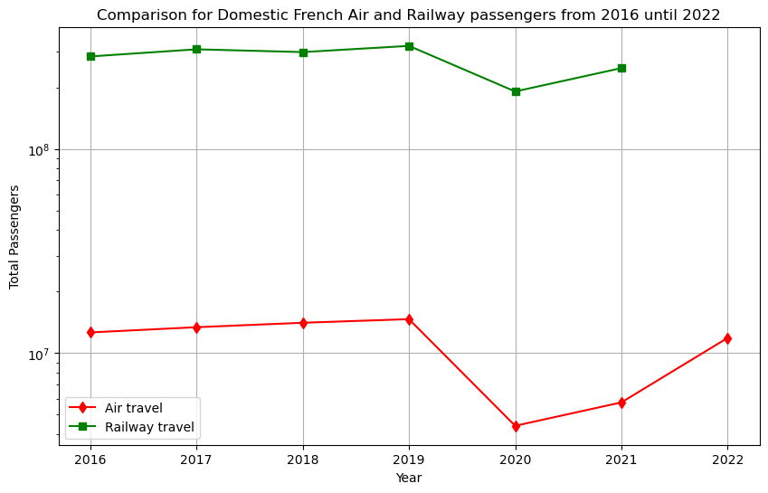

```python
import matplotlib.pyplot as plt

fig, ax = plt.subplots(figsize=(10, 6))

# Specify line colors using the 'color' parameter
ax.plot(air['TIME_PERIOD'], air['WITHIN_FRANCE'], label='Air travel', marker='d', color='red')
ax.plot(rail_FR['TIME_PERIOD'], rail_FR['OBS_VALUE'], label='Railway travel', marker='s', color='green')

ax.set_xlabel('Year')
ax.set_ylabel('Total Passengers')
ax.set_title('Comparison for Domestic French Air and Railway passengers from 2016 until 2022')
ax.grid(True)
ax.legend()

# Set the y-axis to a logarithmic scale
ax.set_yscale('log')

plt.show()
```

# Part 4 - Conclusion

In this final part, the sub research questions will be discussed and the main research question will be answered.

**Our sub research questions:**  
**What is the trend of air travel in the last ten years within the European Union?**  
When looking at the trend of air travel in parts 1 and 2, air travel increased consistently before COVID-19. However, air travel did recover fast after COVID-19 but is still not at the same level of before COVID-19. Therefore, there is no visible trend that travelers swifted away from air travel to other transport means.

**What is the trend of train travel in the last ten years within the European Union?**  
When looking at the trend of train travel in parts 1 and 2, train travel before COVID-19 kept almost consitent over the years. In some countries however, it even became evident that there was a decline. When COVID-19 hit, the decrease in train travel was significant and has not recoverd as of the end of 2022.

**What is the trend of the modal shift to high speed train in France?**  
When looking at the domestic trend in France, there are more passengers travelling via rail than via air. For railway passengers the data for 2022 is missing. Therefore it is hard to conclude how domestic train travel has recovered after COVID-19.

**Our main research question:**  
**What is the trend in the modal shift from air travel to international train travel from the last ten years within the European Union?**  
A shift from international train to air travel is hardly visible, which suspects that this situation does not comply with the goals set by the European Union. COVID-19 had a large influence on both air and rail, although air is recovering faster. Thus, the total European image shows a rather pessimistic trend for international rail advocates. Still, for smaller domestic distances, France proves to be a optimistic example on how trains can form a competetive alternative to planes. Moreover, France scores well on international train passenger numbers as well, which suspects that a robust and competetive domestic network could boost international travel numbers, too.